# Building Randomization in a shiny application

## Rough Draft

When studying the best practices for teaching R, a randomized controlled trial assesses whether there is a relationship between the order students learn R tools, and their ability to complete primary data manipulation tasks. Based on randomization, students learn either tidyverse or base first and then cross over to learn the other modality.

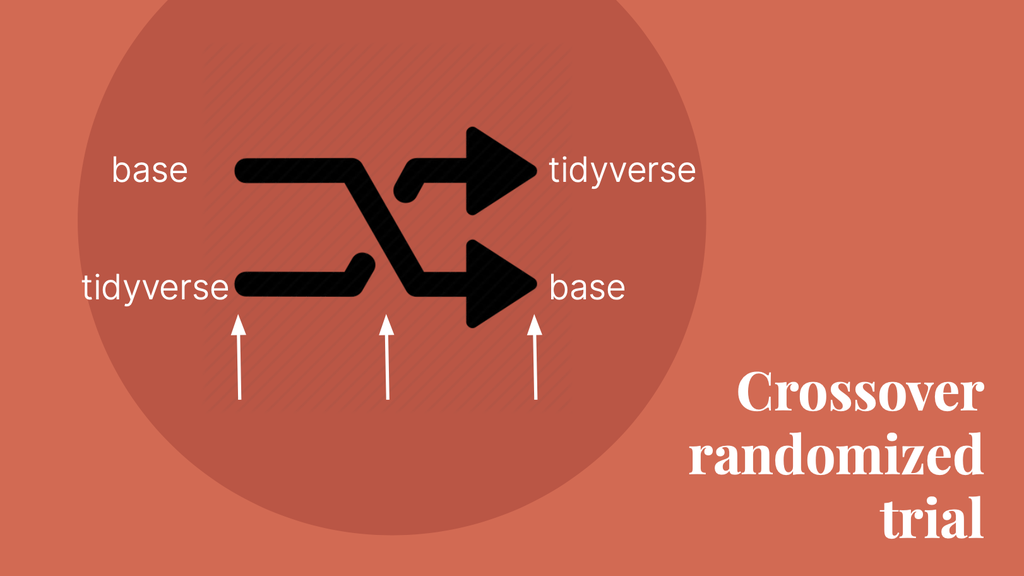

This study used the Shiny software package to create this cross-random trial. This package can host a shiny application as a website that runs R code behind the scenes. For example, the study’s informed consent page automatically randomizes the participant into the tidyverse first group or base first group. The random crossover trial was built using the R Shiny application. A shiny app is a directory structured by two main functions: a server function and a user interface (UI) function.

```r
shinyApp(ui = ui, server = server)
```

The server function is a set of instructions that build the application’s computational components and run complex R code behind the scenes. This mechanism provides vast potential for R shiny user applications and randomization. If input changes, the server will rebuild each output that depends on it. This dependency chain dynamically controls the application’s behavior. In this study, the server function acts as a random number generator to randomize the participants into groups A or B. The function runs a reactive expression containing an R statement, which creates a random uniform variable. If the uniform variable is greater than 0.5, A will be the output; otherwise, B will be the output. The last line of the function makes sure that the created random variable will not suspend when hidden.

```r
server <- function(input, output) {
  output$random <- reactive({
    ifelse(runif(1) > 0.5, "A", "B") })

  outputOptions(output, "random", suspendWhenHidden = FALSE) }
```

The UI function is a set of instructions for the webpage’s layout and appearance; hence, it builds the user-facing side of the application. The conditional panels allow for a set of elements to dynamically show or hide, depending on if meeting the given conditions. In this study, the UI function contains two conditional panels for groups A and B. The selection control only appears when meeting the requirements.

If the random output is A, then the action button opens a new window to the shiny app of order A.

```r
ui <- shinyUI( ...
               conditionalPanel(
                 condition = "output.random == 'A'", actionButton(
                   inputId = "yes",
                   label = "Yes, I agree to this study",
                   icon = icon("check"),
                   onclick = "window.open('http://link-to-order-A.html')"
                   ))
               ...)
```

If the random output is B, then the action button opens a new window to the shiny app of order B.

```r
ui <- shinyUI( ...
               conditionalPanel(
                 condition = "output.random == 'B'", actionButton(
                   inputId = "yes",
                   label = "Yes, I agree to this study",
                   icon = icon("check"),
                   onclick = "window.open('http://link-to-order-B.html')"
                   ))
               ...)
```

With the server function performing the calculations, and the UI function building the user-facing side of the application, a dynamic and interactive shiny app solves many statistical problems tied together with one software mechanism.

McGowan, Lucy D’Agostino. 2020. “Best Practices for Teaching R a Randomized Controlled Trial.” Presentation. *Lucymcgowan.com/Talks*. ocs.google.com/presentation/d/1kOtqXMWhNE6OjInt32PnkBC_j_GfVQ-rJKzFxOn29yM/edit?usp=sharing.